# 空間分析 實習六

電機四 B05901013 張景皓

4/27/2020

## Nearest Neighbour Analysis

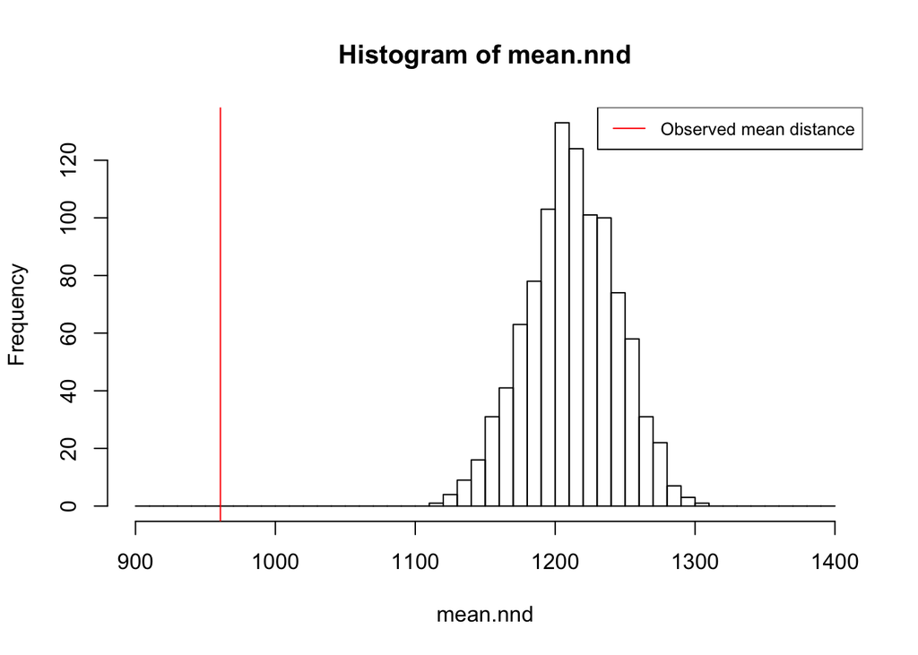

```r
School.nnd <- nndist(X = School.ppp, k = 1);
r.obs <- mean(School.nnd); #960.672
r.exp <- 0.5 / sqrt(nrow(School) / Tainan@polygons[[1]]@area); #1151.972
r.scale <- r.obs / r.exp; #0.834
se = 0.26136 * sqrt(Tainan@polygons[[1]]@area) / nrow(School);
z.score <- (r.obs - r.exp) / se; #-6.542

#NND <- as.numeric(School.nnd);
#hist(NND, breaks = seq(0, 12000, by = 50), right = FALSE);
#abline(v = r.obs, col = "red");
mean.nnd <- c();
for (i in 1:1000) {
  mean.nnd[i] <- mean(nndist(X = rpoint(424, win = Windows), k = 1));
}
hist(mean.nnd, breaks = seq(900, 1400, 10));
abline(v = r.obs, col = "red");
legend("topright", "Observed mean distance", col = "red", lwd = 1, cex = 0.8);
```

According to observational mean distance and expected mean distance of random distribution, the difference of the two ($d = \bar r_\mathrm{obs} - \bar r_\mathrm{exp}$) is less than 0 and the ratio of the two ($R = \frac{r_\mathrm{obs}}{r_\mathrm{exp}}$) is less than 1. In conclusion, the distribution of the schools in Tainan City is clusterd.

### Significance test of NNA

$H_0: \mathrm{School's\ of\ Tainan\ are\ randomly\ distributed.}$  
$H_1: \mathrm{School's\ of\ Tainan\ are\ not\ randomly\ distributed.}$  
The test is carried out at 95% confidence level.

$\mathrm{SE} = \frac{0.26136}{\sqrt{\frac{n^2}{A}}}\approx29.243$  
$Z = \frac{r_\mathrm{obs}-r_\mathrm{exp}}{\mathrm{SE}}\approx-6.542$

The critical values obtained from the z-distribution for $\alpha=0.05$ (two-tailed test) are $\pm1.96$. Therefore, the test fails and $H_0$ is rejected. Alternatively, $H_1$ which states the point pattern is not random is accepted. Since the resulting z score is $-6.542<2\sigma$, indicating the difference is significant and the distribution is clustered.

## K-order Nearest Neightbor Indices

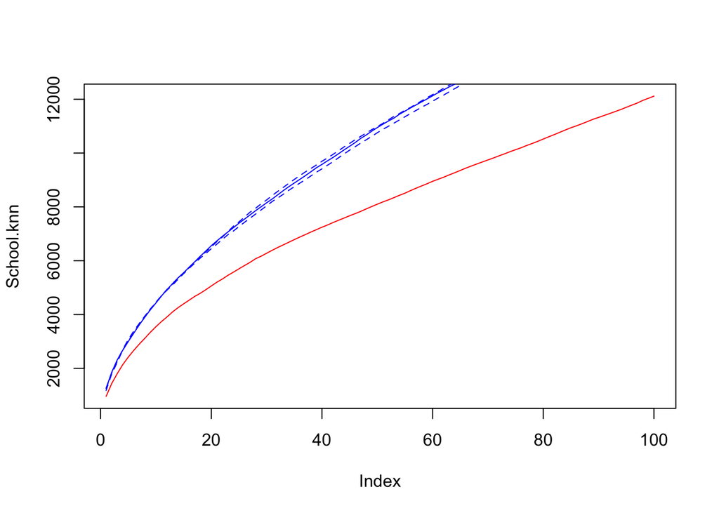

```r
School.knn <- apply(nndist(X = School.ppp, k = 1:100), 2, FUN=mean);

mean <- c();
knn <- list();
for (j in 1:1000) {
  random.points <- rpoint(424, win = Windows);
  mean[j] <- mean(nndist(X = random.points, k = 1));
  knn[[j]] <- apply(nndist(X = random.points, k = 1:100), 2, FUN = mean);
}

mean.df <- data.frame(mean);
mean.df$order <- order(mean);

plot(School.knn, type = "l", col = "red");
lines(knn[[which(mean.df$order == length(mean)*0.05)]], type = "l", col = "blue", lty = "dashed");
lines(knn[[which(mean.df$order == length(mean)*0.5)]], type = "l", col = "blue");
lines(knn[[which(mean.df$order == length(mean)*0.95)]], type = "l", col = "blue", lty = "dashed");
```

### Significance test of K-NNI

$H_0: 5^\mathrm{th} \mathrm{percentile\ KNNI} \leq \mathrm{KNNI}_{obs} \leq 95^\mathrm{th} \mathrm{percentile\ KNNI}$  
$H_1: 5^\mathrm{th} \mathrm{percentile\ KNNI} \geq \mathrm{KNNI}_{obs} \mathrm{\ or\ } \mathrm{KNNI}_{obs} \geq 95^\mathrm{th} \mathrm{percentile\ KNNI}$  
The test is carried out at 95% confidence level.

According to the plot of K-NNI, one can clearly tell that the observational K-NNI does not belong to the interval between 5th/95th percentile K-NNI. Therefore, the test fails and $H_0$ is rejected. Alternatively, $H_1$ which states the point pattern is not random is accepted. Since the observational K-NNI lies way under the 5th percentile K-NNI, indicating the difference is significant and the distribution is clustered.

## G Function

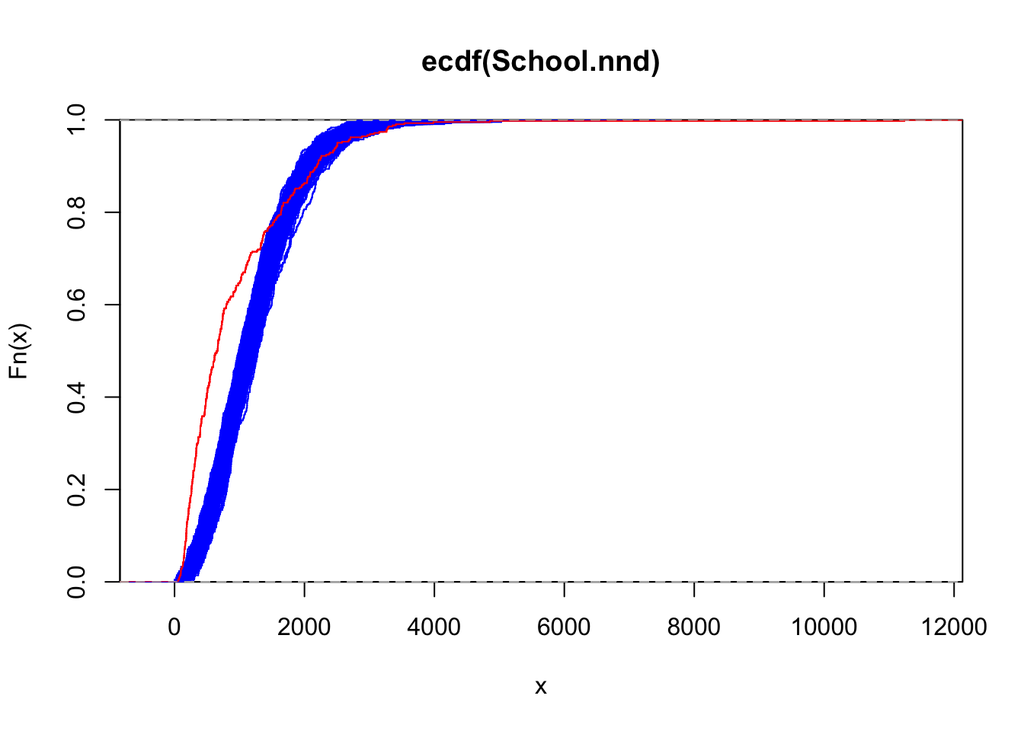

```r
School.G <- ecdf(School.nnd);
plot(School.G, col = "red", cex = 0, verticals = TRUE, xaxs = "i", yaxs = "i");

for (k in 1:1000) {
  nnd <- nndist(X = rpoint(424, win = Windows), k = 1);
  G <- ecdf(nnd);
  plot(G, col = "blue", add = TRUE, cex = 0, verticals = TRUE, xaxs = "i", yaxs = "i");
}

plot(School.G, col = "red", add = TRUE, cex = 0, verticals = TRUE, xaxs = "i", yaxs = "i");
```

### Significance test of G Function

H0: The G function plot of the distribution of the schools of Tainan lies within the envelope of G function plots of the random distributioin, indicating the schools are randomly distributed.  
H1: The G function plot of the distribution of the schools of Tainan does not lie within the envelope of G function plots of the random distributioin, indicating the schools are not randomly distributed.